# Part I - (Used Car Data Exploration)

## The relationship between mileage and selling price with variations in fuel types and transmission types

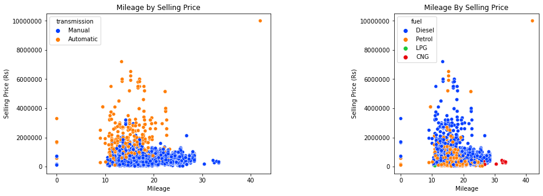

```python
#plotting a plot to show the relationship between mileage and  the fuel types, transmission and selling price

plt.figure(figsize = [15,5])
plt.subplot(1,2,1)
ax = plt.gca()
ax.ticklabel_format(useOffset=False, style='plain')
sns.scatterplot(data = used_car,x = 'mileage',y = 'selling_price',palette = 'bright',hue ='transmission' );
ax.set_title('Mileage by Selling Price')
ax.set_xlabel('Mileage')
ax.set_ylabel('Selling Price (Rs)')
plt.subplot(1,3,3)
ax = plt.gca()
ax.ticklabel_format(useOffset=False, style='plain')
sns.scatterplot(data = used_car,x = 'mileage',y = 'selling_price',palette = 'bright',hue = 'fuel' );
ax.set_title('Mileage By Selling Price')
ax.set_xlabel('Mileage')
ax.set_ylabel('Selling Price (Rs)');
```

Observation

For mileage of 10-20 there is a increase of selling price for the automatic transmission while for mileage of 20 we have a significant increase in selling price of above 4000000 for the Diesel and also for fuel types as the data points are scattered comparetively

## The Relationship between Fuel and Selling Price and Sold Status

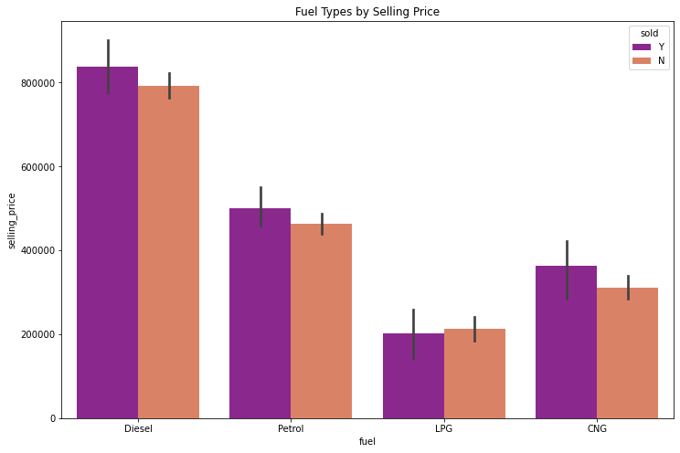

```python
plt.figure(figsize =(12,8))
ax = plt.gca()
ax.ticklabel_format(useOffset=False, style='plain')
ax.set_title('Fuel Types by Selling Price')
ax.set_ylabel('Selling Price')
ax.set_xlabel('Fuel Types');
sns.barplot(data = used_car,x = 'fuel',y = 'selling_price',hue ='sold',palette = 'plasma');
```

Observation it shows that ratio between sold between the sold and unsold is almost compartively to each other maybe because of the used cars being unsold for a range of years

# Insights Gained During Multivariate Exploration

from the year 1995 to 2004 most of the used cars were unsold for all the fuel types but peaked in 2005 to 2020, 2020 was the year diesel had the highest selling price

The Diesel had the highest price with the Automatic Transmission than the Manuel for Year 2020, while for Manual Diesel had the highest for 2020

For mileage of 10-20 there is a increase of selling price for the automatic transmission.

## Conclusion

Among many features it can be said that Year, Name, Region are categories which affect buying and selling of car.

Fuel feature the diesel type, does predict the price of the car but it has no significat relation to its being sold and unsold

Mileage and Km_Driven doesn't affect price,it can be observed that cars with mileage close to 30 are being sold compared to cars with low mileage and most of the cars have not been driven for long and that could also be factor why they dont command a high price.

Most of the used_car were unsold from 1995 to 2010. From 2010 to 2020 there was an increase of sales and price

Most of the used cars are on first owner basis and this commands a high selling price compare to the others. and most of first owner basis are sold more this could be a good determing factor for price